# Demography

Ernesto Carrella

March 2, 2016

## Demography

A simple demo of how the model keeps track of recruits, mortality and ages per fish.

I have coded in the recruitment formulas in Steve’s spreadsheets. Here I am using Dover Sole numbers and parameters to show how its population evolves when there is no fishing pressure. Most of the work ahead is to disperse this fish geographically but for now I think it’s important to make sure this looks right:

[video not shown]

Notice how “predictable” the simulated generations are since the mortality rate is constant year after year. This is somewhat different from the actual distribution and I wonder if it something to be worried about.

Here I plot the total number of recruits over the year. There is a small dip before increasing again, which might make sense since spawning biomass is both at numerator and denominator. What I don’t really understand though is why this number does not converge to the $R_0$ parameter which I seem to understand is the number of recruits we’d expect at the “virgin” state of no exploitation. The $R_0$ parameter here is the horizontal line:

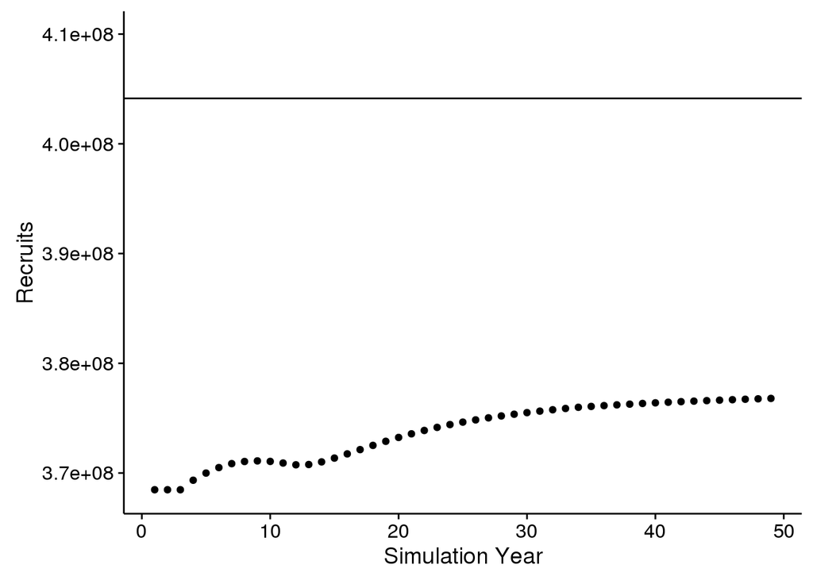

Even running the recruitment for 10,000 years does not bring the total number of recruits to $R_0$. This might be simply because the $\Phi$ parameter is off or I should consider older classes of fish as well and so on.